# Project: NYC Schools Perceptions

Abie A

The dataset is publicly available at: combined.csv: https://data.world/dataquest/nyc-schools-data/workspace/file?filename=combined.csv NYC school survey data for 2011: https://data.cityofnewyork.us/Education/2011-NYC-School-Survey/mnz3-dyi8

We will try to answer the following questions:

Do student, teacher, and parent perceptions of NYC school quality appear to be related to demographic and academic success metrics?

Do students, teachers, and parents have similar perceptions of NYC school quality?

First, let’s load the required libraries:

```r
library(readr)
library(dplyr)
library(purrr)
library(ggplot2)
library(stringr)
library(tidyr)
```

Let’s import the data that we cleaned from the previous courses.

```r
combined <- read_csv(file.choose())
```

Next, we’ll import the survey data. The txt survey data is separated by tabs so we will use read_tsv() from the readr library to import the files masterfile11_gened_final.txt and masterfile11_d75_final.txt

```r
masterfile1_gened <- read_tsv((file.choose()))
masterfile1_d75 <- read_tsv(file.choose())
```

Let’s check out the data that we’ve imported:

```r
head(masterfile1_gened,5)
```

| dbn | bn | schoolname | d75 | studentssurveyed | highschool | schooltype | rr_s | rr_t | rr_p | N_s | N_t | N_p | nr_s | nr_t | nr_p | saf_p_11 | com_p_11 | eng_p_11 | aca_p_11 | saf_t_11 | com_t_11 | eng_t_11 | aca_t_11 | saf_s_11 | com_s_11 | eng_s_11 | aca_s_11 | saf_tot_11 | com_tot_11 | … |
| --- | --- | --- | --- | --- | --- | --- | --- | --- | --- | --- | --- | --- | --- | --- | --- | --- | --- | --- | --- | --- | --- | --- | --- | --- | --- | --- | --- | --- | --- | --- |
| 01M015 | M015 | P.S. 015 Roberto Clemente | 0 | No | 0 | Elementary School | NA | 88 | 60 | NA | 22 | 90 | 0 | 25 | 150 | 8.5 | 7.6 | 7.5 | 7.8 | 7.5 | 7.8 | 7.6 | 7.9 | NA | NA | NA | NA | 8.0 | 7.7 | … |
| 01M019 | M019 | P.S. 019 Asher Levy | 0 | No | 0 | Elementary School | NA | 100 | 60 | NA | 34 | 161 | 0 | 33 | 269 | 8.4 | 7.6 | 7.6 | 7.8 | 8.6 | 8.5 | 8.9 | 9.1 | NA | NA | NA | NA | 8.5 | 8.1 | … |
| 01M020 | M020 | P.S. 020 Anna Silver | 0 | No | 0 | Elementary School | NA | 88 | 73 | NA | 42 | 367 | 0 | 48 | 505 | 8.9 | 8.3 | 8.3 | 8.6 | 7.6 | 6.3 | 6.8 | 7.5 | NA | NA | NA | NA | 8.2 | 7.3 | … |
| 01M034 | M034 | P.S. 034 Franklin D. Roosevelt | 0 | Yes | 0 | Elementary / Middle School | 89 | 73 | 50 | 145 | 29 | 151 | 163 | 40 | 301 | 8.8 | 8.2 | 8.0 | 8.5 | 7.0 | 6.2 | 6.8 | 7.8 | 6.2 | 5.9 | 6.5 | 7.4 | 7.3 | 6.7 | … |
| 01M063 | M063 | P.S. 063 William McKinley | 0 | No | 0 | Elementary School | NA | 100 | 60 | NA | 23 | 90 | 0 | 23 | 151 | 8.7 | 7.9 | 8.1 | 7.9 | 8.4 | 7.3 | 7.8 | 8.1 | NA | NA | NA | NA | 8.5 | 7.6 | … |

```r
head(masterfile1_d75,5)
```

| dbn | bn | schoolname | d75 | studentssurveyed | highschool | schooltype | rr_s | rr_t | rr_p | N_s | N_t | N_p | nr_s | nr_t | nr_p | saf_p_11 | com_p_11 | eng_p_11 | aca_p_11 | saf_t_11 | com_t_11 | eng_t_11 | aca_t_11 | saf_s_11 | com_s_11 | eng_s_11 | aca_s_11 | saf_tot_11 | com_tot_11 | … |
| --- | --- | --- | --- | --- | --- | --- | --- | --- | --- | --- | --- | --- | --- | --- | --- | --- | --- | --- | --- | --- | --- | --- | --- | --- | --- | --- | --- | --- | --- | --- |
| 75K004 | K004 | P.S. K004 | 1 | Yes | 0 | District 75 Special Education | 38 | 90 | 72 | 8 | 81 | 244 | 21 | 90 | 337 | 9.1 | 8.6 | 8.4 | 8.5 | 7.4 | 6.6 | 6.4 | 6.4 | 7.6 | 5.8 | 7.6 | 6.3 | 8.0 | 7.0 | … |
| 75K036 | K036 | P.S. 36 | 1 | Yes | NA | District 75 Special Education | 70 | 69 | 44 | 97 | 43 | 115 | 139 | 62 | 263 | 9.2 | 8.7 | 8.6 | 8.8 | 6.9 | 7.1 | 6.1 | 7.2 | 6.6 | 6.9 | 7.3 | 7.7 | 7.5 | 7.6 | … |
| 75K053 | K053 | P.S. K053 | 1 | Yes | NA | District 75 Special Education | 94 | 97 | 53 | 131 | 75 | 189 | 139 | 77 | 355 | 8.8 | 8.1 | 8.0 | 8.1 | 7.8 | 7.5 | 6.9 | 8.0 | 8.2 | 7.7 | 8.6 | 8.5 | 8.2 | 7.8 | … |
| 75K077 | K077 | P.S. K077 | 1 | Yes | NA | District 75 Special Education | 95 | 65 | 55 | 70 | 52 | 150 | 74 | 80 | 274 | 9.4 | 8.7 | 8.8 | 8.9 | 7.1 | 6.2 | 6.4 | 6.3 | 8.6 | 8.3 | 8.6 | 8.8 | 8.3 | 7.7 | … |
| 75K140 | K140 | P.S. K140 | 1 | Yes | 0 | District 75 Special Education | 77 | 70 | 42 | 69 | 45 | 117 | 90 | 64 | 277 | 8.6 | 8.2 | 7.9 | 8.3 | 5.6 | 5.8 | 5.1 | 6.0 | 4.7 | 6.1 | 6.0 | 7.3 | 6.3 | 6.7 | … |

We can see that the dataframes contain columns that are not relevant to our analysis. Let’s create a dataframe by selecting only the relevant columns.

```r
gened <- masterfile1_gened %>%
  filter(schooltype == "High School") %>%
  select(DBN = dbn, schoolname, rr_s:aca_tot_11)

head(gened,5)
```

| DBN | schoolname | rr_s | rr_t | rr_p | N_s | N_t | N_p | nr_s | nr_t | nr_p | saf_p_11 | com_p_11 | eng_p_11 | aca_p_11 | saf_t_11 | com_t_11 | eng_t_11 | aca_t_11 | saf_s_11 | com_s_11 | eng_s_11 | aca_s_11 | saf_tot_11 | com_tot_11 | eng_tot_11 | aca_tot_11 |
| --- | --- | --- | --- | --- | --- | --- | --- | --- | --- | --- | --- | --- | --- | --- | --- | --- | --- | --- | --- | --- | --- | --- | --- | --- | --- | --- |
| 01M448 | University Neighborhood High School | 84 | 95 | 10 | 385 | 37 | 46 | 459 | 39 | 445 | 7.9 | 7.4 | 7.2 | 7.3 | 6.6 | 5.8 | 6.6 | 7.3 | 6.0 | 5.7 | 6.3 | 7.0 | 6.8 | 6.3 | 6.7 | 7.2 |
| 01M458 | Forsyth Satellite Academy | 40 | 100 | 23 | 66 | 10 | 37 | 167 | 10 | 164 | 8.1 | 7.0 | 6.7 | 7.6 | 8.5 | 8.2 | 8.9 | 8.9 | 6.8 | 6.1 | 6.1 | 6.8 | 7.8 | 7.1 | 7.2 | 7.8 |
| 01M509 | Marta Valle High School | 90 | 100 | 21 | 306 | 29 | 69 | 339 | 28 | 325 | 7.7 | 7.4 | 7.2 | 7.3 | 6.4 | 5.3 | 6.1 | 6.8 | 6.4 | 5.9 | 6.4 | 7.0 | 6.9 | 6.2 | 6.6 | 7.0 |
| 01M515 | Lower East Side Preparatory High School | 95 | 100 | 86 | 454 | 36 | 389 | 477 | 36 | 450 | 8.3 | 7.2 | 7.4 | 7.5 | 9.1 | 7.3 | 8.7 | 9.1 | 8.0 | 6.3 | 7.0 | 7.3 | 8.5 | 7.0 | 7.7 | 8.0 |
| 01M650 | Cascades High School | 75 | 86 | 19 | 125 | 12 | 30 | 166 | 14 | 158 | 9.0 | 8.4 | 8.1 | 8.6 | 7.6 | 7.5 | 8.3 | 8.7 | 8.1 | 6.9 | 7.9 | 8.4 | 8.3 | 7.6 | 8.1 | 8.6 |

Next, we’ll simplify the d75 dataframe.

```r
d75 <- masterfile1_d75 %>%
  select(DBN=dbn,schoolname,studentssurveyed:aca_tot_11)

head(d75,5)
```

| DBN | schoolname | studentssurveyed | highschool | schooltype | rr_s | rr_t | rr_p | N_s | N_t | N_p | nr_s | nr_t | nr_p | saf_p_11 | com_p_11 | eng_p_11 | aca_p_11 | saf_t_11 | com_t_11 | eng_t_11 | aca_t_11 | saf_s_11 | com_s_11 | eng_s_11 | aca_s_11 | saf_tot_11 | com_tot_11 | eng_tot_11 | aca_tot_11 |
| --- | --- | --- | --- | --- | --- | --- | --- | --- | --- | --- | --- | --- | --- | --- | --- | --- | --- | --- | --- | --- | --- | --- | --- | --- | --- | --- | --- | --- | --- |
| 75K004 | P.S. K004 | Yes | 0 | District 75 Special Education | 38 | 90 | 72 | 8 | 81 | 244 | 21 | 90 | 337 | 9.1 | 8.6 | 8.4 | 8.5 | 7.4 | 6.6 | 6.4 | 6.4 | 7.6 | 5.8 | 7.6 | 6.3 | 8.0 | 7.0 | 7.5 | 7.1 |
| 75K036 | P.S. 36 | Yes | NA | District 75 Special Education | 70 | 69 | 44 | 97 | 43 | 115 | 139 | 62 | 263 | 9.2 | 8.7 | 8.6 | 8.8 | 6.9 | 7.1 | 6.1 | 7.2 | 6.6 | 6.9 | 7.3 | 7.7 | 7.5 | 7.6 | 7.3 | 7.9 |
| 75K053 | P.S. K053 | Yes | NA | District 75 Special Education | 94 | 97 | 53 | 131 | 75 | 189 | 139 | 77 | 355 | 8.8 | 8.1 | 8.0 | 8.1 | 7.8 | 7.5 | 6.9 | 8.0 | 8.2 | 7.7 | 8.6 | 8.5 | 8.2 | 7.8 | 7.8 | 8.2 |
| 75K077 | P.S. K077 | Yes | NA | District 75 Special Education | 95 | 65 | 55 | 70 | 52 | 150 | 74 | 80 | 274 | 9.4 | 8.7 | 8.8 | 8.9 | 7.1 | 6.2 | 6.4 | 6.3 | 8.6 | 8.3 | 8.6 | 8.8 | 8.3 | 7.7 | 7.9 | 8.0 |
| 75K140 | P.S. K140 | Yes | 0 | District 75 Special Education | 77 | 70 | 42 | 69 | 45 | 117 | 90 | 64 | 277 | 8.6 | 8.2 | 7.9 | 8.3 | 5.6 | 5.8 | 5.1 | 6.0 | 4.7 | 6.1 | 6.0 | 7.3 | 6.3 | 6.7 | 6.3 | 7.2 |

We can now combine the gened and d75 dataframes as we have scaled down the number of columns.

```r
survey <- bind_rows(gened,d75)

survey
```

| DBN | schoolname | rr_s | rr_t | rr_p | N_s | N_t | N_p | nr_s | nr_t | nr_p | saf_p_11 | com_p_11 | eng_p_11 | aca_p_11 | saf_t_11 | com_t_11 | eng_t_11 | aca_t_11 | saf_s_11 | com_s_11 | eng_s_11 | aca_s_11 | saf_tot_11 | com_tot_11 | eng_tot_11 | aca_tot_11 | studentssurveyed | highschool | schooltype |
| --- | --- | --- | --- | --- | --- | --- | --- | --- | --- | --- | --- | --- | --- | --- | --- | --- | --- | --- | --- | --- | --- | --- | --- | --- | --- | --- | --- | --- | --- |
| 01M448 | University Neighborhood High School | 84 | 95 | 10 | 385 | 37 | 46 | 459 | 39 | 445 | 7.9 | 7.4 | 7.2 | 7.3 | 6.6 | 5.8 | 6.6 | 7.3 | 6.0 | 5.7 | 6.3 | 7.0 | 6.8 | 6.3 | 6.7 | 7.2 | NA | NA | NA |
| 01M458 | Forsyth Satellite Academy | 40 | 100 | 23 | 66 | 10 | 37 | 167 | 10 | 164 | 8.1 | 7.0 | 6.7 | 7.6 | 8.5 | 8.2 | 8.9 | 8.9 | 6.8 | 6.1 | 6.1 | 6.8 | 7.8 | 7.1 | 7.2 | 7.8 | NA | NA | NA |
| 01M509 | Marta Valle High School | 90 | 100 | 21 | 306 | 29 | 69 | 339 | 28 | 325 | 7.7 | 7.4 | 7.2 | 7.3 | 6.4 | 5.3 | 6.1 | 6.8 | 6.4 | 5.9 | 6.4 | 7.0 | 6.9 | 6.2 | 6.6 | 7.0 | NA | NA | NA |
| 01M515 | Lower East Side Preparatory High School | 95 | 100 | 86 | 454 | 36 | 389 | 477 | 36 | 450 | 8.3 | 7.2 | 7.4 | 7.5 | 9.1 | 7.3 | 8.7 | 9.1 | 8.0 | 6.3 | 7.0 | 7.3 | 8.5 | 7.0 | 7.7 | 8.0 | NA | NA | NA |
| 01M650 | Cascades High School | 75 | 86 | 19 | 125 | 12 | 30 | 166 | 14 | 158 | 9.0 | 8.4 | 8.1 | 8.6 | 7.6 | 7.5 | 8.3 | 8.7 | 8.1 | 6.9 | 7.9 | 8.4 | 8.3 | 7.6 | 8.1 | 8.6 | NA | NA | NA |
| 01M696 | Bard High School Early College | 98 | 81 | 50 | 561 | 30 | 283 | 571 | 37 | 561 | 8.8 | 8.2 | 8.3 | 9.1 | 8.2 | 7.4 | 7.5 | 8.3 | 8.3 | 7.3 | 8.0 | 8.9 | 8.5 | 7.6 | 8.0 | 8.7 | NA | NA | NA |
| 02M047 | 47 The American Sign Language and English Secondar | 72 | 76 | 30 | 109 | 16 | 43 | 152 | 21 | 145 | 8.9 | 7.7 | 7.9 | 8.1 | 8.1 | 6.1 | 7.7 | 7.2 | 7.3 | 6.3 | 7.0 | 7.5 | 8.1 | 6.7 | 7.5 | 7.6 | NA | NA | NA |
| 02M288 | Food and Finance High School | 86 | 100 | 57 | 348 | 35 | 229 | 407 | 31 | 405 | 7.6 | 7.0 | 6.9 | 7.6 | 7.3 | 7.1 | 7.8 | 7.7 | 6.2 | 5.7 | 6.1 | 7.2 | 7.0 | 6.6 | 6.9 | 7.5 | NA | NA | NA |
| 02M294 | Essex Street Academy | 48 | 56 | 9 | 150 | 15 | 28 | 314 | 27 | 306 | 8.7 | 8.1 | 7.9 | 8.3 | 8.0 | 7.7 | 7.9 | 8.9 | 7.4 | 6.5 | 7.3 | 7.6 | 7.9 | 7.3 | 7.7 | 8.2 | NA | NA | NA |
| 02M296 | High School of Hospitality Management | 61 | 96 | 56 | 233 | 27 | 204 | 385 | 28 | 365 | 8.0 | 7.3 | 7.1 | 7.5 | 8.6 | 8.1 | 8.7 | 8.9 | 7.1 | 6.5 | 7.0 | 7.4 | 7.9 | 7.3 | 7.6 | 8.0 | NA | NA | NA |

[output cut: 429 more lines]

Let’s combine the survey dataframe with our combined df using left join so that we can retain all observations in the combined df and those matching records in the survey df.The key for our join is the DBN variable which exists in all our dataframes.

```r
combinedsurvey <- combined %>%
  left_join(survey, by = "DBN")

combinedsurvey
```

| DBN | school_name | Num of SAT Test Takers | SAT Critical Reading Avg. Score | SAT Math Avg. Score | SAT Writing Avg. Score | avg_sat_score | AP Test Takers | Total Exams Taken | Number of Exams with scores 3 4 or 5 | exams_per_student | high_score_percent | avg_class_size | frl_percent | total_enrollment | ell_percent | sped_percent | selfcontained_num | asian_per | black_per | hispanic_per | white_per | male_per | female_per | Total Cohort | grads_percent | dropout_percent | boro | lat | long | … |
| --- | --- | --- | --- | --- | --- | --- | --- | --- | --- | --- | --- | --- | --- | --- | --- | --- | --- | --- | --- | --- | --- | --- | --- | --- | --- | --- | --- | --- | --- | --- |
| 01M292 | HENRY STREET SCHOOL FOR INTERNATIONAL STUDIES | 29 | 355 | 404 | 363 | 1122 | 2.5 | NA | NA | NA | NA | 23 | 88.6 | 422 | 22.3 | 24.9 | 35 | 14.0 | 29.1 | 53.8 | 1.7 | 61.4 | 38.6 | 78 | 55.1 | 14.1 | Manhattan | 40.71376 | -73.98526 | … |
| 01M448 | UNIVERSITY NEIGHBORHOOD HIGH SCHOOL | 91 | 383 | 423 | 366 | 1172 | 39.0 | 49 | 10 | 1.256410 | 20.408163 | 22 | 71.8 | 394 | 21.1 | 21.8 | 10 | 29.2 | 22.6 | 45.9 | 2.3 | 57.4 | 42.6 | 124 | 42.7 | 16.1 | Manhattan | 40.71233 | -73.98480 | … |
| 01M450 | EAST SIDE COMMUNITY SCHOOL | 70 | 377 | 402 | 370 | 1149 | 19.0 | 21 | NA | 1.105263 | NA | 21 | 71.8 | 598 | 5.0 | 26.4 | 19 | 9.7 | 23.9 | 55.4 | 10.4 | 54.7 | 45.3 | 90 | 77.8 | 5.6 | Manhattan | 40.72978 | -73.98304 | … |
| 01M458 | FORSYTH SATELLITE ACADEMY | 7 | 414 | 401 | 359 | 1174 | 2.5 | NA | NA | NA | NA | 23 | 72.8 | 224 | 4.0 | 8.9 | 0 | 2.2 | 34.4 | 59.4 | 3.6 | 43.3 | 56.7 | NA | NA | NA | NA | NA | NA | … |
| 01M509 | MARTA VALLE HIGH SCHOOL | 44 | 390 | 433 | 384 | 1207 | 2.5 | NA | NA | NA | NA | 24 | 80.7 | 367 | 11.2 | 25.9 | 36 | 9.3 | 31.6 | 56.9 | 1.6 | 46.3 | 53.7 | 84 | 56.0 | 6.0 | Manhattan | 40.72057 | -73.98567 | … |
| 01M515 | LOWER EAST SIDE PREPARATORY HIGH SCHOOL | 112 | 332 | 557 | 316 | 1205 | 24.0 | 26 | 24 | 1.083333 | 92.307692 | 23 | NA | NA | NA | NA | NA | NA | NA | NA | NA | NA | NA | 193 | 54.4 | 18.1 | NA | NA | NA | … |
| 01M539 | NEW EXPLORATIONS INTO SCIENCE, TECHNOLOGY AND MATH HIGH SCHOOL | 159 | 522 | 574 | 525 | 1621 | 255.0 | 377 | 191 | 1.478431 | 50.663130 | 26 | 23.0 | 1613 | 0.2 | 2.7 | 0 | 27.8 | 11.7 | 14.2 | 44.9 | 49.2 | 50.8 | 46 | 100.0 | 0.0 | Manhattan | 40.71873 | -73.97943 | … |
| 01M650 | CASCADES HIGH SCHOOL | 18 | 417 | 418 | 411 | 1246 | 2.5 | NA | NA | NA | NA | 22 | 69.8 | 218 | 3.2 | 6.9 | 0 | 0.5 | 45.4 | 49.5 | 4.1 | 39.9 | 60.1 | 89 | 55.1 | 6.7 | NA | NA | NA | … |
| 01M696 | BARD HIGH SCHOOL EARLY COLLEGE | 130 | 624 | 604 | 628 | 1856 | 2.5 | NA | NA | NA | NA | 21 | 18.0 | 617 | 0.2 | 0.8 | 0 | 15.1 | 15.1 | 18.2 | 49.8 | 31.3 | 68.7 | 139 | 96.4 | 0.7 | Manhattan | 40.71896 | -73.97607 | … |
| 02M047 | 47 THE AMERICAN SIGN LANGUAGE AND ENGLISH SECONDARY SCHOOL | 16 | 395 | 400 | 387 | 1182 | 2.5 | NA | NA | NA | NA | 16 | 66.9 | 174 | 8.0 | 32.2 | 10 | 1.7 | 32.2 | 59.2 | 6.3 | 42.5 | 57.5 | 25 | 76.0 | 4.0 | Manhattan | 40.73860 | -73.98251 | … |

[output cut: 469 more lines]

Let’s look for relationships between variables by creating a correlation marix.

```r
corr_mat <- combinedsurvey %>%
  select(avg_sat_score, saf_p_11:aca_tot_11) %>%
  cor(use = "pairwise.complete.obs")

corr_mat
```

```
              avg_sat_score   saf_p_11   com_p_11  eng_p_11    aca_p_11  saf_t_11  com_t_11   eng_t_11  aca_t_11  saf_s_11  com_s_11  eng_s_11  aca_s_11 saf_tot_11 com_tot_11 eng_tot_11
avg_sat_score   1.000000000 0.08913424 -0.1139639 0.0094307 0.008276863 0.3091444 0.1074703 0.05612571 0.1411575 0.2772681 0.1623022 0.1703460 0.2925880  0.2760410 0.08909856 0.09479407
saf_p_11        0.089134237 1.00000000  0.8029932 0.7984741 0.817219807 0.4904652 0.2316462 0.31403333 0.3642311 0.7324148 0.6169158 0.6474957 0.6919735  0.8276467 0.64231997 0.66370163
com_p_11       -0.113963937 0.80299315  1.0000000 0.9291268 0.925565838 0.3149366 0.2411942 0.30718612 0.3470251 0.5411576 0.5687691 0.5913392 0.6146925  0.6105585 0.69339241 0.67145808
eng_p_11        0.009430700 0.79847408  0.9291268 1.0000000 0.907884041 0.3392305 0.2675333 0.32966966 0.3585188 0.5390565 0.5450478 0.6075781 0.6236426  0.6209748 0.68203559 0.71010958
aca_p_11        0.008276863 0.81721981  0.9255658 0.9078840 1.000000000 0.4154006 0.2858248 0.37341858 0.4190859 0.5930388 0.5980923 0.6227372 0.6798373  0.6828482 0.71198853 0.72003487
saf_t_11        0.309144422 0.49046519  0.3149366 0.3392305 0.415400554 1.0000000 0.7437526 0.79946285 0.8448628 0.5922487 0.3825288 0.4565140 0.4932720  0.8435345 0.73636889 0.75687379
com_t_11        0.107470334 0.23164622  0.2411942 0.2675333 0.285824766 0.7437526 1.0000000 0.90329649 0.8960927 0.2527900 0.1683019 0.2585602 0.2652035  0.5074542 0.79972327 0.72146902
eng_t_11        0.056125707 0.31403333  0.3071861 0.3296697 0.373418577 0.7994629 0.9032965 1.00000000 0.9498147 0.3678941 0.2887301 0.3578421 0.3593602  0.6084624 0.80356551 0.83787593
aca_t_11        0.141157527 0.36423106  0.3470251 0.3585188 0.419085881 0.8448628 0.8960927 0.94981468 1.0000000 0.4186507 0.3239221 0.3881175 0.4089070  0.6660397 0.82363320 0.82760652
saf_s_11        0.277268115 0.73241477  0.5411576 0.5390565 0.593038790 0.5922487 0.2527900 0.36789407 0.4186507 1.0000000 0.8227886 0.8847919 0.8719545  0.8908945 0.64126689 0.70789667
com_s_11        0.162302236 0.61691582  0.5687691 0.5450478 0.598092320 0.3825288 0.1683019 0.28873011 0.3239221 0.8227886 1.0000000 0.8836172 0.8649279  0.6907220 0.65751381 0.65915031
eng_s_11        0.170346019 0.64749568  0.5913392 0.6075781 0.622737241 0.4565140 0.2585602 0.35784213 0.3881175 0.8847919 0.8836172 1.0000000 0.9213798  0.7573247 0.68395614 0.75920793
aca_s_11        0.292587986 0.69197352  0.6146925 0.6236426 0.679837302 0.4932720 0.2652035 0.35936021 0.4089070 0.8719545 0.8649279 0.9213798 1.0000000  0.7855468 0.69009358 0.73953389
saf_tot_11      0.276041045 0.82764669  0.6105585 0.6209748 0.682848168 0.8435345 0.5074542 0.60846241 0.6660397 0.8908945 0.6907220 0.7573247 0.7855468  1.0000000 0.79013553 0.83403143
com_tot_11      0.089098561 0.64231997  0.6933924 0.6820356 0.711988528 0.7363689 0.7997233 0.80356551 0.8236332 0.6412669 0.6575138 0.6839561 0.6900936  0.7901355 1.00000000 0.93995349
eng_tot_11      0.094794066 0.66370163  0.6714581 0.7101096 0.720034872 0.7568738 0.7214690 0.83787593 0.8276065 0.7078967 0.6591503 0.7592079 0.7395339  0.8340314 0.93995349 1.00000000
aca_tot_11      0.173800408 0.70043795  0.7028261 0.7054661 0.789215088 0.7817245 0.6943313 0.78680846 0.8445192 0.7142941 0.6597831 0.7208915 0.7778084  0.8601577 0.93174674 0.95256492
              aca_tot_11
avg_sat_score  0.1738004
saf_p_11       0.7004380
com_p_11       0.7028261
eng_p_11       0.7054661
aca_p_11       0.7892151
saf_t_11       0.7817245
com_t_11       0.6943313
eng_t_11       0.7868085
aca_t_11       0.8445192
saf_s_11       0.7142941
com_s_11       0.6597831
eng_s_11       0.7208915
aca_s_11       0.7778084
saf_tot_11     0.8601577
com_tot_11     0.9317467
eng_tot_11     0.9525649
aca_tot_11     1.0000000
```

Convert matrix to tibble to allow for easier interpretation.

```r
corr_tibble <- corr_mat %>%
  as_tibble(rownames = "variable")

corr_tibble
```

| variable | avg_sat_score | saf_p_11 | com_p_11 | eng_p_11 | aca_p_11 | saf_t_11 | com_t_11 | eng_t_11 | aca_t_11 | saf_s_11 | com_s_11 | eng_s_11 | aca_s_11 | saf_tot_11 | com_tot_11 | eng_tot_11 | aca_tot_11 |
| --- | --- | --- | --- | --- | --- | --- | --- | --- | --- | --- | --- | --- | --- | --- | --- | --- | --- |
| avg_sat_score | 1.000000000 | 0.08913424 | -0.1139639 | 0.0094307 | 0.008276863 | 0.3091444 | 0.1074703 | 0.05612571 | 0.1411575 | 0.2772681 | 0.1623022 | 0.1703460 | 0.2925880 | 0.2760410 | 0.08909856 | 0.09479407 | 0.1738004 |
| saf_p_11 | 0.089134237 | 1.00000000 | 0.8029932 | 0.7984741 | 0.817219807 | 0.4904652 | 0.2316462 | 0.31403333 | 0.3642311 | 0.7324148 | 0.6169158 | 0.6474957 | 0.6919735 | 0.8276467 | 0.64231997 | 0.66370163 | 0.7004380 |
| com_p_11 | -0.113963937 | 0.80299315 | 1.0000000 | 0.9291268 | 0.925565838 | 0.3149366 | 0.2411942 | 0.30718612 | 0.3470251 | 0.5411576 | 0.5687691 | 0.5913392 | 0.6146925 | 0.6105585 | 0.69339241 | 0.67145808 | 0.7028261 |
| eng_p_11 | 0.009430700 | 0.79847408 | 0.9291268 | 1.0000000 | 0.907884041 | 0.3392305 | 0.2675333 | 0.32966966 | 0.3585188 | 0.5390565 | 0.5450478 | 0.6075781 | 0.6236426 | 0.6209748 | 0.68203559 | 0.71010958 | 0.7054661 |
| aca_p_11 | 0.008276863 | 0.81721981 | 0.9255658 | 0.9078840 | 1.000000000 | 0.4154006 | 0.2858248 | 0.37341858 | 0.4190859 | 0.5930388 | 0.5980923 | 0.6227372 | 0.6798373 | 0.6828482 | 0.71198853 | 0.72003487 | 0.7892151 |
| saf_t_11 | 0.309144422 | 0.49046519 | 0.3149366 | 0.3392305 | 0.415400554 | 1.0000000 | 0.7437526 | 0.79946285 | 0.8448628 | 0.5922487 | 0.3825288 | 0.4565140 | 0.4932720 | 0.8435345 | 0.73636889 | 0.75687379 | 0.7817245 |
| com_t_11 | 0.107470334 | 0.23164622 | 0.2411942 | 0.2675333 | 0.285824766 | 0.7437526 | 1.0000000 | 0.90329649 | 0.8960927 | 0.2527900 | 0.1683019 | 0.2585602 | 0.2652035 | 0.5074542 | 0.79972327 | 0.72146902 | 0.6943313 |
| eng_t_11 | 0.056125707 | 0.31403333 | 0.3071861 | 0.3296697 | 0.373418577 | 0.7994629 | 0.9032965 | 1.00000000 | 0.9498147 | 0.3678941 | 0.2887301 | 0.3578421 | 0.3593602 | 0.6084624 | 0.80356551 | 0.83787593 | 0.7868085 |
| aca_t_11 | 0.141157527 | 0.36423106 | 0.3470251 | 0.3585188 | 0.419085881 | 0.8448628 | 0.8960927 | 0.94981468 | 1.0000000 | 0.4186507 | 0.3239221 | 0.3881175 | 0.4089070 | 0.6660397 | 0.82363320 | 0.82760652 | 0.8445192 |
| saf_s_11 | 0.277268115 | 0.73241477 | 0.5411576 | 0.5390565 | 0.593038790 | 0.5922487 | 0.2527900 | 0.36789407 | 0.4186507 | 1.0000000 | 0.8227886 | 0.8847919 | 0.8719545 | 0.8908945 | 0.64126689 | 0.70789667 | 0.7142941 |

[output cut: 7 more lines]

Filter for strong correlations bet `avg_sat_score` and other variables: greater than 0.25 or less than -0.25

```r
strong_cor <- corr_tibble %>%
  select(variable, avg_sat_score) %>%
  filter(avg_sat_score > 0.25 | avg_sat_score < -0.25)

strong_cor
```

| variable | avg_sat_score |
| --- | --- |
| avg_sat_score | 1.0000000 |
| saf_t_11 | 0.3091444 |
| saf_s_11 | 0.2772681 |
| aca_s_11 | 0.2925880 |
| saf_tot_11 | 0.2760410 |

Create scatterplots to visualize relationships.

```r
#create a function to efficiently create scatterplots
scattergen <- function(x,y) {
  ggplot(data=combinedsurvey) +
    aes_string(x = x,y = y) +
    geom_point(alpha=0.3) +
    theme(panel.background = element_rect(fill = "white"))
}

strong_cor$variable
```

```
[1] "avg_sat_score" "saf_t_11"      "saf_s_11"      "aca_s_11"      "saf_tot_11"
```

```r
y_var = strong_cor$variable[1]
x_var = strong_cor$variable[2:5]

y_var
```

```
[1] "avg_sat_score"
```

```r
x_var
```

```
[1] "saf_t_11"   "saf_s_11"   "aca_s_11"   "saf_tot_11"
```

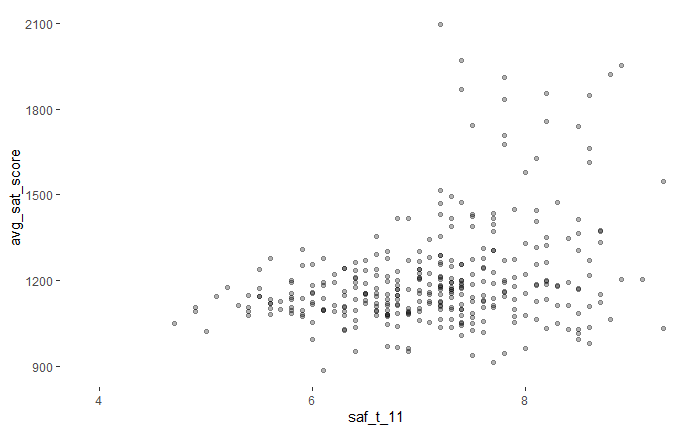

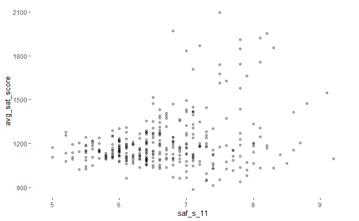

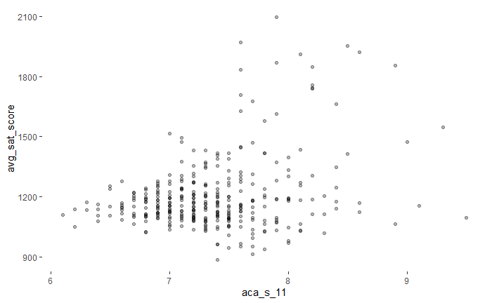

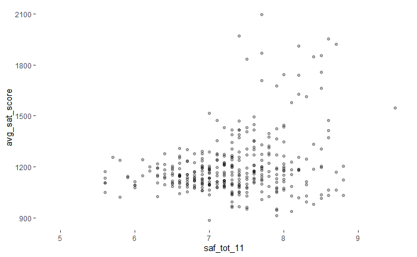

```r
map2(x_var,y_var,scattergen)
```

From the scatterplots, we can see that there is a positive relationship between avg_sat_score and saf_t_11 (Safety and Respect score based on teacher responses), saf_s_11(safety and respect score based on student responses), aca_s_11 (academic expectations score based on student responses) and saf_tot_11 (safety and respect total score).

Our next step is to reshape the data with the so that the survey question (e.g., saf_p_11) and the corresponding score are in two separate columns:

```r
combinedlong <- combinedsurvey %>%
  pivot_longer(cols = c(saf_p_11:aca_tot_11), names_to = "survey_question", values_to = "score" )

combinedlong
```

| DBN | school_name | Num of SAT Test Takers | SAT Critical Reading Avg. Score | SAT Math Avg. Score | SAT Writing Avg. Score | avg_sat_score | AP Test Takers | Total Exams Taken | Number of Exams with scores 3 4 or 5 | exams_per_student | high_score_percent | avg_class_size | frl_percent | total_enrollment | ell_percent | sped_percent | selfcontained_num | asian_per | black_per | hispanic_per | white_per | male_per | female_per | Total Cohort | grads_percent | dropout_percent | boro | lat | long | … |
| --- | --- | --- | --- | --- | --- | --- | --- | --- | --- | --- | --- | --- | --- | --- | --- | --- | --- | --- | --- | --- | --- | --- | --- | --- | --- | --- | --- | --- | --- | --- |
| 01M292 | HENRY STREET SCHOOL FOR INTERNATIONAL STUDIES | 29 | 355 | 404 | 363 | 1122 | 2.5 | NA | NA | NA | NA | 23 | 88.6 | 422 | 22.3 | 24.9 | 35 | 14.0 | 29.1 | 53.8 | 1.7 | 61.4 | 38.6 | 78 | 55.1 | 14.1 | Manhattan | 40.71376 | -73.98526 | … |
| 01M292 | HENRY STREET SCHOOL FOR INTERNATIONAL STUDIES | 29 | 355 | 404 | 363 | 1122 | 2.5 | NA | NA | NA | NA | 23 | 88.6 | 422 | 22.3 | 24.9 | 35 | 14.0 | 29.1 | 53.8 | 1.7 | 61.4 | 38.6 | 78 | 55.1 | 14.1 | Manhattan | 40.71376 | -73.98526 | … |
| 01M292 | HENRY STREET SCHOOL FOR INTERNATIONAL STUDIES | 29 | 355 | 404 | 363 | 1122 | 2.5 | NA | NA | NA | NA | 23 | 88.6 | 422 | 22.3 | 24.9 | 35 | 14.0 | 29.1 | 53.8 | 1.7 | 61.4 | 38.6 | 78 | 55.1 | 14.1 | Manhattan | 40.71376 | -73.98526 | … |
| 01M292 | HENRY STREET SCHOOL FOR INTERNATIONAL STUDIES | 29 | 355 | 404 | 363 | 1122 | 2.5 | NA | NA | NA | NA | 23 | 88.6 | 422 | 22.3 | 24.9 | 35 | 14.0 | 29.1 | 53.8 | 1.7 | 61.4 | 38.6 | 78 | 55.1 | 14.1 | Manhattan | 40.71376 | -73.98526 | … |
| 01M292 | HENRY STREET SCHOOL FOR INTERNATIONAL STUDIES | 29 | 355 | 404 | 363 | 1122 | 2.5 | NA | NA | NA | NA | 23 | 88.6 | 422 | 22.3 | 24.9 | 35 | 14.0 | 29.1 | 53.8 | 1.7 | 61.4 | 38.6 | 78 | 55.1 | 14.1 | Manhattan | 40.71376 | -73.98526 | … |
| 01M292 | HENRY STREET SCHOOL FOR INTERNATIONAL STUDIES | 29 | 355 | 404 | 363 | 1122 | 2.5 | NA | NA | NA | NA | 23 | 88.6 | 422 | 22.3 | 24.9 | 35 | 14.0 | 29.1 | 53.8 | 1.7 | 61.4 | 38.6 | 78 | 55.1 | 14.1 | Manhattan | 40.71376 | -73.98526 | … |
| 01M292 | HENRY STREET SCHOOL FOR INTERNATIONAL STUDIES | 29 | 355 | 404 | 363 | 1122 | 2.5 | NA | NA | NA | NA | 23 | 88.6 | 422 | 22.3 | 24.9 | 35 | 14.0 | 29.1 | 53.8 | 1.7 | 61.4 | 38.6 | 78 | 55.1 | 14.1 | Manhattan | 40.71376 | -73.98526 | … |
| 01M292 | HENRY STREET SCHOOL FOR INTERNATIONAL STUDIES | 29 | 355 | 404 | 363 | 1122 | 2.5 | NA | NA | NA | NA | 23 | 88.6 | 422 | 22.3 | 24.9 | 35 | 14.0 | 29.1 | 53.8 | 1.7 | 61.4 | 38.6 | 78 | 55.1 | 14.1 | Manhattan | 40.71376 | -73.98526 | … |
| 01M292 | HENRY STREET SCHOOL FOR INTERNATIONAL STUDIES | 29 | 355 | 404 | 363 | 1122 | 2.5 | NA | NA | NA | NA | 23 | 88.6 | 422 | 22.3 | 24.9 | 35 | 14.0 | 29.1 | 53.8 | 1.7 | 61.4 | 38.6 | 78 | 55.1 | 14.1 | Manhattan | 40.71376 | -73.98526 | … |
| 01M292 | HENRY STREET SCHOOL FOR INTERNATIONAL STUDIES | 29 | 355 | 404 | 363 | 1122 | 2.5 | NA | NA | NA | NA | 23 | 88.6 | 422 | 22.3 | 24.9 | 35 | 14.0 | 29.1 | 53.8 | 1.7 | 61.4 | 38.6 | 78 | 55.1 | 14.1 | Manhattan | 40.71376 | -73.98526 | … |

[output cut: 990 more lines]

Next, we will create a new variable to indicate the different response types for parent, teacher, student and total.We will call this variable response_type. We will also create a new variable “metric” which is also derived from the survey_question variable.

```r
combinedlong <-  combinedlong %>%
  mutate(response_type = ifelse(substr(survey_question,4,6) == "_p_", "parent",
                                ifelse(substr(survey_question,4,6) == "_s_", "student",
                                       ifelse(substr(survey_question,4,6) == "_t_", "teacher",
                                              ifelse(substr(survey_question,4,6) == "_to","total", "NA"))))) %>%
  mutate(metric = ifelse(substr(survey_question,1,3) == "eng", "engagement",
                         ifelse(substr(survey_question,1,3) == "aca", "academic",
                                ifelse(substr(survey_question,1,3) == "saf", "safety", "communication"))))

combinedlong
```

| DBN | school_name | Num of SAT Test Takers | SAT Critical Reading Avg. Score | SAT Math Avg. Score | SAT Writing Avg. Score | avg_sat_score | AP Test Takers | Total Exams Taken | Number of Exams with scores 3 4 or 5 | exams_per_student | high_score_percent | avg_class_size | frl_percent | total_enrollment | ell_percent | sped_percent | selfcontained_num | asian_per | black_per | hispanic_per | white_per | male_per | female_per | Total Cohort | grads_percent | dropout_percent | boro | lat | long | … |
| --- | --- | --- | --- | --- | --- | --- | --- | --- | --- | --- | --- | --- | --- | --- | --- | --- | --- | --- | --- | --- | --- | --- | --- | --- | --- | --- | --- | --- | --- | --- |
| 01M292 | HENRY STREET SCHOOL FOR INTERNATIONAL STUDIES | 29 | 355 | 404 | 363 | 1122 | 2.5 | NA | NA | NA | NA | 23 | 88.6 | 422 | 22.3 | 24.9 | 35 | 14.0 | 29.1 | 53.8 | 1.7 | 61.4 | 38.6 | 78 | 55.1 | 14.1 | Manhattan | 40.71376 | -73.98526 | … |
| 01M292 | HENRY STREET SCHOOL FOR INTERNATIONAL STUDIES | 29 | 355 | 404 | 363 | 1122 | 2.5 | NA | NA | NA | NA | 23 | 88.6 | 422 | 22.3 | 24.9 | 35 | 14.0 | 29.1 | 53.8 | 1.7 | 61.4 | 38.6 | 78 | 55.1 | 14.1 | Manhattan | 40.71376 | -73.98526 | … |
| 01M292 | HENRY STREET SCHOOL FOR INTERNATIONAL STUDIES | 29 | 355 | 404 | 363 | 1122 | 2.5 | NA | NA | NA | NA | 23 | 88.6 | 422 | 22.3 | 24.9 | 35 | 14.0 | 29.1 | 53.8 | 1.7 | 61.4 | 38.6 | 78 | 55.1 | 14.1 | Manhattan | 40.71376 | -73.98526 | … |
| 01M292 | HENRY STREET SCHOOL FOR INTERNATIONAL STUDIES | 29 | 355 | 404 | 363 | 1122 | 2.5 | NA | NA | NA | NA | 23 | 88.6 | 422 | 22.3 | 24.9 | 35 | 14.0 | 29.1 | 53.8 | 1.7 | 61.4 | 38.6 | 78 | 55.1 | 14.1 | Manhattan | 40.71376 | -73.98526 | … |
| 01M292 | HENRY STREET SCHOOL FOR INTERNATIONAL STUDIES | 29 | 355 | 404 | 363 | 1122 | 2.5 | NA | NA | NA | NA | 23 | 88.6 | 422 | 22.3 | 24.9 | 35 | 14.0 | 29.1 | 53.8 | 1.7 | 61.4 | 38.6 | 78 | 55.1 | 14.1 | Manhattan | 40.71376 | -73.98526 | … |
| 01M292 | HENRY STREET SCHOOL FOR INTERNATIONAL STUDIES | 29 | 355 | 404 | 363 | 1122 | 2.5 | NA | NA | NA | NA | 23 | 88.6 | 422 | 22.3 | 24.9 | 35 | 14.0 | 29.1 | 53.8 | 1.7 | 61.4 | 38.6 | 78 | 55.1 | 14.1 | Manhattan | 40.71376 | -73.98526 | … |
| 01M292 | HENRY STREET SCHOOL FOR INTERNATIONAL STUDIES | 29 | 355 | 404 | 363 | 1122 | 2.5 | NA | NA | NA | NA | 23 | 88.6 | 422 | 22.3 | 24.9 | 35 | 14.0 | 29.1 | 53.8 | 1.7 | 61.4 | 38.6 | 78 | 55.1 | 14.1 | Manhattan | 40.71376 | -73.98526 | … |
| 01M292 | HENRY STREET SCHOOL FOR INTERNATIONAL STUDIES | 29 | 355 | 404 | 363 | 1122 | 2.5 | NA | NA | NA | NA | 23 | 88.6 | 422 | 22.3 | 24.9 | 35 | 14.0 | 29.1 | 53.8 | 1.7 | 61.4 | 38.6 | 78 | 55.1 | 14.1 | Manhattan | 40.71376 | -73.98526 | … |
| 01M292 | HENRY STREET SCHOOL FOR INTERNATIONAL STUDIES | 29 | 355 | 404 | 363 | 1122 | 2.5 | NA | NA | NA | NA | 23 | 88.6 | 422 | 22.3 | 24.9 | 35 | 14.0 | 29.1 | 53.8 | 1.7 | 61.4 | 38.6 | 78 | 55.1 | 14.1 | Manhattan | 40.71376 | -73.98526 | … |
| 01M292 | HENRY STREET SCHOOL FOR INTERNATIONAL STUDIES | 29 | 355 | 404 | 363 | 1122 | 2.5 | NA | NA | NA | NA | 23 | 88.6 | 422 | 22.3 | 24.9 | 35 | 14.0 | 29.1 | 53.8 | 1.7 | 61.4 | 38.6 | 78 | 55.1 | 14.1 | Manhattan | 40.71376 | -73.98526 | … |

[output cut: 990 more lines]

Let’s visualize the differences between the responses of parents, teachers and students with respect to the metric:

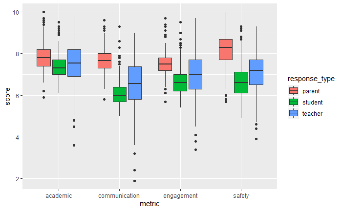

```r
vizdata <- combinedlong %>%
  filter(response_type != "total")

ggplot(data=vizdata) +
  aes(x=metric, y=score, fill = response_type) +
  geom_boxplot()
```